# Fluoridation Surveillance Framework Proposal

# Fluoridation Surveillance Project Specification: Response Outline (md.UPDATED WITH EDITS FROM WORD DOC draft 3)

*Structured against the letter’s three evaluation criteria: methodology (40%), timeframe (20%), cost (40%).

## 1. Introduction, Scope and Track Record

Short statement acknowledging the invitation, confirming the response addresses methodology, timeframe and cost as requested.

**A note on naming/scope, to state explicitly up front:** the letter’s title refers to a “fluoridation surveillance” model, but Pillar 1 (fluoride concentration in public water supplies) is explicitly excluded from this call. What’s actually being specified is a model for Pillars 2 and 3, oral and systemic health surveillance in a population exposed to community water fluoridation, not a system for measuring fluoride itself. We should probably frame the specification accordingly: a national oral and general health surveillance system, stratified by CWF exposure status, rather than a fluoride monitoring system in the literal sense. This affects what the minimum exposure variable needs to be (see 2.4).

**Confirmed by the Department (reply from Anne Murphy):**

- **Budget confirmed**: as we discussed this morning, the €5,000 is “the Department’s budget for engaging services to carry out the necessary overview project to develop and deliver the project specification itself.” This is a fee for producing the specification document, not for building or running the surveillance system it describes (see Section 4).
- **Primary data sources narrowed to three**: the Department names only Uisce Éireann, TILDA and GUI as “primary.” HSE and NHES, both in the original letter’s list, aren’t repeated here. Worth reading as a signal of priority, not as dropping HSE/IUNA from the analysis entirely
- **Uisce Éireann now points to a public-facing tool**: “Detailed drinking water quality results for your Water Supply Zone,” a consumer portal. Needs checking for what granularity and history it actually gives (current snapshot only, or a time series).we are pretty sure this is just the one monthly reading from UE which is then available on EPA-SAFER files. As we discussed, this is probably why they have omitted Pillar 1, but this is fairly coarse data, once/month consumer level, and we dont know anything about sampling/how representative etc.
- **National Oral Health Policy, “Smile agus Sláinte,” Chapter 10** (“Oral health evaluation, policy evaluation and research development”) is flagged as the policy anchor for this work.
- **WHO reference is the *Global strategy and action plan on oral health 2023-2030*, specifically** Strategic Objective 5, “Oral health information systems.”**
- **Healthy Ireland**: the Department points specifically to the **2022 Healthy Ireland Survey**, which “most recently held a standalone module on dental and oral health.”I have added an outline doc to Onedrive which I was planning to look at HI data , might be useful to understadn what’s in it.
- **Prior FSWG evidence base named directly**:
  - HRB 2023 Evidence Brief on water fluoridation surveillance in four case countries (international comparator models).
  - HRB umbrella review, *Effect of artificial community water fluoridation on dental health* (May 2025).
  - HRB umbrella review, *Health Effects of Water Fluoridation* (2015).
  - HRB umbrella review, *Impact of community water fluoridation on systemic health excluding oral health*.

  These three reviews plus the evidence brief are the actual evidence base the FSWG has already commissioned.

### 1.1 Existing Programme and Data Assets

This proposal is not written from a standing start. It draws on an active, HRB-funded research programme at TCD/DDUH that has already built and tested large parts of the infrastructure this specification is being asked to describe:

**Feasibility at a glance**

[output not shown]

## 2. Proposed Methodology (40%)

### 2.1 Review of Existing National Data Sources

What each source currently holds, relevant to fluoride surveillance:

- **TILDA**: clinical oral health examination data on an ageing adult cohort, plus residential history that supports linkage to water supply exposure. The only source with both clinical exam data and exposure-linkage potential in the same cohort, and the one already used for this purpose (see 1.1).
- **GUI (Growing Up in Ireland)**: longitudinal child/adolescent cohort with geocoded addresses (supports WSZ linkage), but no clinical oral health examination, oral health is not part of its protocol. Some self/parent-reported items (e.g. toothbrushing, dental visits, fillings, extractions) exist in some survey waves.
- **National Survey of Children’s Oral Health (OHSRC, UCC)**: the historic clinical dataset directly linking fluoridation status to dmft/DMFT and enamel fluorosis in 5, 8, 12 and 15 year olds. Confirmed: no national round since 2002. This is the most significant single gap in the current evidence base.
- **FACCT (Fluoride And Caring for Children’s Teeth, UCC/HSE, HRB-funded)**: clinical exam data on children born either side of the 2007 CWF policy change and 2002 toothpaste policy change, ages 5 and 12, fieldwork in 2013/14. Directly designed to evaluate CWF policy impact, but regional (Dublin, Cork, Kerry), not national, and a one-off study. Its exposure-classification rules were reused in the 2016 HRB TILDA fluoridation grant (see 1.1) and remain a directly reusable methodological asset.
- **HBSC Ireland (Health Behaviour in School-aged Children, University of Galway/WHO)**: self-report survey of school-going children aged 9-18, every 4 years since 1998 (most recent 2022). No clinical oral health data, but tracks toothbrushing frequency and sugar-sweetened drink consumption, useful exposure/behavioural covariates for the age band GUI and TILDA don’t cover.
- **HSE (PCRS)**: administrative claims data on dental treatments (fillings, extractions) funded through the Dental Treatment Services Scheme, a proxy for disease burden rather than a direct exam, but useful as a systemic indicator.
- **HSE Salaried Dental Services**: school dental screening records (where they occur, e.g. senior infants, 5th/6th class) are the closest thing to population-level child oral health exam data, but they’re generated locally by CHO area and not centrally aggregated for research use.
- **Uisce Éireann**: daily operational dosing/testing logs at treatment plants, held internally, not published; the new public WSZ water-quality portal (see Section 1) may add a partial public-facing layer.(NB CONFRIM THIS IS SAME DATA AS EPA_SAFER DATA FILES)
- **NHES / HSE Public Analyst Laboratories**: monthly statutory tap-water testing verifying the 0.6–0.8 mg/L target, aggregated into regional annual reports; raw monthly data held administratively. Note: a 52-year (1964–2016) compiled and cleaned version of this class of data already exists and is held by this team, see Section 1.1.
- **IUNA**: national dietary surveys (adults, children, pre-school) with detailed food and beverage consumption data, the input needed to model dietary fluoride intake. This is primarily consumption data and isn’t paired with a maintained fluoride food-content database (the last Irish-specific fluoride food analysis was the standalone FSAI study, 2014-2016). However, two of the eight IUNA waves do carry oral-health-relevant items: **NCFS II (2017-18)** includes toothbrushing frequency, fluoridated toothpaste use and dental check-up attendance, and **NTFS II (2019-20)** includes sugar-sweetened beverage intake alongside self-reported oral hygiene behaviour. These are behavioural frequency items, not fluoride-dose data, so they support the toothpaste/behaviour side of exposure modelling (2.5) without closing the underlying food-composition gap.
- **Healthy Ireland (HI) Survey**: annual population health behaviours survey; potential source for self-reported oral health behaviours and for the “public feedback” element the letter asks about, though it’s self-report, not clinical. The Department specifically flags the 2022 round, which carried a standalone dental and oral health module (~10 items: toothbrushing, dental visits, self-rated oral health, and others), stronger than the 2018 round’s ~4 general behaviour items. HI also covers general health, smoking, alcohol, weight management, HSU.(I ADDED OUR OWN SUMMARY pdf to Onedrive )
- **Irish Health Survey (CSO, modelled on the EU’s EHIS)**: distinct from Healthy Ireland; self-report, includes dental consultation/visit questions and a general dental health rating, now has a children’s health module (2024). Regularly run, adult and child coverage, but self-report only.
- **Oral Health of Irish Adults (2000-2002)**: older national adult oral health survey, predates TILDA’s oral health module; a possible historical comparator but not recurring.

### 2.2 Data Gaps and Barriers to Access

- **No child oral health examination data exists at national level.** GUI doesn’t collect it, and HSE school screening data, where it happens, isn’t centrally digitised or held in a form available for research linkage. This is arguably the single biggest gap in the current landscape for Pillar 3, and is consistent with the wider policy analysis of universal child oral health coverage in Ireland (McAuliffe, 2025).
- **CSO Research Microdata File (RMF) access for GUI**: GUI microdata, including the geocodes needed for water supply linkage, sits behind CSO-controlled RMF access (Section 30, Statistics Act 1993). This is slow, restricts what can be exported, and each linkage use case likely needs its own approval, not a standing arrangement.(this is a big stumbling block at moment with HRB, they wont release any data untill all of the files are done and we can only submit ONE project application)
- **Water fluoride data (Pillar 1) is administratively fragmented across custodians for the current period, but a large part of the historical problem is already solved.** Uisce Éireann, HSE Public Analyst Labs and EPA SAFER each hold pieces of the picture, and only the EPA’s annual aggregate is easily accessible. What changes this from a research problem to a data-sharing problem is that this team already holds a cleaned, linkable 1964–2016 national archive (Section 1.1). The genuine remaining gap is (a) extending that archive from 2016 to the present, and (b) formalising ongoing access to monthly/current data rather than reassembling history from scratch.
- **IUNA dietary data has no current fluoride-content linkage**, the food composition database needed to convert consumption data into fluoride intake estimates would need to be rebuilt or sourced. Self-reported toothbrushing/toothpaste-use items in NCFS II and NTFS II help on the behavioural side but don’t resolve this.
- **No single legal/governance gateway** currently exists to link across these sources (CSO, HSE, Uisce Éireann, IUNA, academic cohorts); each pairing needs its own agreement.

### 2.3 Barriers to Developing New Surveillance Mechanisms

(The letter specifically flags sentinel practices, non-target ages, and compliance with the WHO’s *Global strategy and action plan on oral health 2023-2030*, Strategic Objective 5, “Oral health information systems,” per the Department’s own citation.)

  | SOHSS/NOHSS domain | US indicator example | Plausible Irish equivalent |
  | --- | --- | --- |
  | Burden of oral disease | Caries/sealants in 3rd-grade children; complete tooth loss in older adults | Repeat national child oral health survey (OHSRC-style) if reinstated; TILDA tooth retention data |
  | Delivery system utilisation | Annual dentist visit rate; Medicaid dental care use | Healthy Ireland dental module; DTSS claims via HSE PCRS |
  | Community-level prevention | % population on optimally fluoridated water; school sealant programme reach | Uisce Éireann/NHES fluoridation compliance data (Section 1.1 archive); HSE school sealant/screening programme reach where recorded |

### 2.4 Pillar 1 and the Exposure Variable

The letter excludes Pillar 1 as a piece of *work*: this specification isn’t being asked to design, operate or redesign fluoride monitoring at treatment plants and taps, that’s a separate, already-functioning statutory system (Uisce Éireann daily operational testing, HSE Public Analyst monthly statutory testing, EPA SAFER annual compliance archive). It does not mean the continuous concentration data that system already produces is unavailable as an input to this framework.

So rather than falling back to a simple fluoridated/non-fluoridated categorical flag, the proposal should specify that the model ingests fluoride concentration data as a continuous exposure variable at Water Supply Zone level, enabling a proper dose-level analysis rather than a binary comparison (which is what the 2002 OHSRC survey and FACCT were limited to). This respects the letter’s exclusion, we’re not proposing to build or alter Pillar 1 monitoring itself, while making full use of what it already produces. Two things de-risk this considerably beyond where the argument stood in earlier drafts:

1. **The historical half of the problem is already solved.** This team’s own 52-year archive (1964–2016, Section 1.1) is exactly this continuous, WSZ-attributable concentration data, already cleaned and analysed once. The genuine remaining barrier isn’t data existence, it’s currency (extending 2016 to the present) and access/aggregation, a data-sharing and governance task, not a monitoring-design task.
2. Section 6(1) of the Health (Fluoridation of Water Supplies) Act 1960 places a duty on the Minister to arrange for surveys relating to the health of persons supplied with fluoridated water. The 2016 HRB grant application (Section 1.1) notes explicitly that no such survey had, at that point, ever been established.

### 2.5 Total Fluoride Exposure Modelling (Diet and Toothpaste)

Water fluoride alone does not capture total exposure. The 2014 FSAI Total Diet Study remains the last Ireland-specific modelling of dietary fluoride, and toothpaste ingestion was flagged then as unmodelled. EFSA’s 2025 update does not close this gap: it uses aggregate EU dietary data (not Irish-specific) and a blanket 100% toothpaste ingestion assumption rather than Irish behavioural data. The IUNA NCFS II (2017-18) and NTFS II (2019-20) waves add self-reported toothbrushing frequency and fluoridated toothpaste use, which helps ground the behavioural side of a toothpaste exposure model in Irish data for the first time, but this is frequency/use data, not an ingested-dose estimate, and doesn’t touch the dietary food-composition gap. Modelling total Irish fluoride exposure (diet plus topical) should remain an explicit, separately scoped component of the framework, not assumed solved by either the IUNA items or the EFSA update.

## 3. Estimated Timeframe (20%)

[output not shown]

The existence of the assets in Section 1.1, a compiled historical fluoride archive and a proven WSZ linkage pipeline, materially reduces the risk of this timeline slipping, since the two most technically demanding components (spatial linkage methodology, historical Pillar 1 data assembly) do not need to be designed from first principles. This timeline should still be confirmed against the FSWG’s actual reference documentation once received, it’s built on the letter’s stated deadlines and typical desk-review project structure, not on materials specific to this project.

## 4. Total Cost (40%)

Two separate figures are relevant here and should not be conflated.

### 4.1 Cost to deliver this specification (our quoted fee)

Confirmed by the Department: the €5,000 is the budget “for engaging services to carry out the necessary overview project to develop and deliver the project specification itself,” not a fee for the tender submission and not a budget for building or running the surveillance system described. This is the fee to be quoted against the scope in Section 2, once timeframe (Section 3) is finalised.

Since cost carries 40% of the evaluation, an itemised breakdown against the four phases in Section 3 is likely to score better than a single lump figure. An illustrative structure, to be populated with real names and rates before submission:

| Work package | Phase | Indicative hours | Indicative cost |
| --- | --- | --- | --- |
| Evidence review and data source synthesis (Section 2.1) | 1 | ~30 | ~€2,400 |
| Governance and barrier analysis, incl. CSO RMF and WHO/SOHSS alignment (2.2–2.3) | 2 | ~15 | ~€1,350 |
| Exposure/integration model design (2.4–2.6) and final report writing (Phase 4) | 3–4 | ~10 | ~€750 |
| **Total** |  |  | **~€4,500** |

These hours and rates are placeholders, not a costed commitment, and need to be replaced with the actual rates and division of labour across the team before submission. Whether the final figure should be quoted inclusive or exclusive of VAT needs confirming against the institution’s VAT status for this type of engagement; this hasn’t been checked and shouldn’t be assumed either way.

### 4.2 Indicative cost of the surveillance framework itself (a specification output, not our fee)

The letter asks for “a costed proposal for a new clinical health surveillance model” as part of the specification’s own content, distinct from what it costs to write the specification. This is a genuinely difficult figure to give at this stage, since the final design (which pillars, which age bands, sentinel network or not, extent of new data collection) is exactly what the specification work will determine. As a placeholder order of magnitude, pending detailed scoping, an indicative range of **€50,000–€250,000** is suggested, this is deliberately wide, reflects that the low end assumes largely a linkage/governance exercise over existing data (TILDA, GUI, the existing fluoride archive) and the high end assumes new data collection (e.g. a sentinel network or a repeat national child oral health survey). This figure should be treated as illustrative only and refined substantially once the specification’s methodology is agreed, not quoted to the Department as a firm estimate at this stage.

## References Cited

- Abdelrahman, H.H., Hamza, M., Essam, W. et al. (2024). Electronic oral health surveillance system for Egyptian preschoolers using District Health Information System (DHIS2): design description and time motion study. *BMC Oral Health*. https://doi.org/10.1186/s12903-024-04550-w
- Council of State and Territorial Epidemiologists / Association of State and Territorial Dental Directors (2013). State-Based Oral Health Surveillance Systems (white paper). https://www.astdd.org/docs/state-based-oral-health-surveillance-systems-cste-whitepaper-oct-2013.pdf
- Cosgrave, E., Sheridan, A., Kavanagh, P. et al. (2023). Inequalities in oral health service utilisation in Ireland: results from the Healthy Ireland Survey. *European Journal of Public Health*. https://doi.org/10.1093/eurpub/ckad160.769
- Leavy, P., Fleming, P., Daly, B. et al. (2025). Primary oral healthcare in Ireland: a health systems analysis of publicly funded contracted services delivered by the general dental practitioner workforce. *BMC Health Services Research*. https://doi.org/10.1186/s12913-025-12884-6
- Malvitz, D.M., Barker, L.K., Phipps, K.R. (2009). Development and status of the National Oral Health Surveillance System.
- McAuliffe, Ú., Whelton, H., Harding, M. et al. (2022). ‘Toothless’: the absence of political priority for oral health, a case study of Ireland 1994-2021. *BMC Oral Health*. https://doi.org/10.1186/s12903-022-02125-1
- McAuliffe, Ú. (2025). A health systems and policy analysis to inform universal child oral health coverage and Irish oral health reform.
- Prado, I.M.S., Frazão, P. (2019). Qualidade dos dados de vigilância da fluoretação de sistemas de abastecimento de água: proposta de um protocolo de crítica dos dados. https://doi.org/10.22239/2317-269x.01297
- Ramasubbu, D., Lewney, J., Duane, B. (2026). Service Evaluation of HSE Oral Health Promotion and Improvement Programmes in Ireland (preprint). https://doi.org/10.21203/rs.3.rs-10041165/v1
- Sharma, V., O’Connell, B., O’Flaherty, E., Rigby, J., McLoughlin, J., Cronin, M., O’Sullivan, M., Winning, L., Cassetti, O., Crowe, M. (2026). Longitudinal Analysis of Fluoride Levels in Irish Water Supplies: A 52-Year Review. *Community Dentistry and Oral Epidemiology*. https://doi.org/10.1111/cdoe.70055

*The comparator/policy references above (Abdelrahman, Cosgrave, Leavy, Malvitz, McAuliffe x2, Prado, Ramasubbu) were located via the OpenAIRE Graph connector and screened by title/abstract only, worth a full read before the proposal goes out. The Sharma et al. (2026) entry is the team’s own published output and has been read in full. HRB grant APA-2016-1882 is cited in-text as an internal precedent (unpublished application) rather than listed here as a public reference.*

## Appendix A: Illustrative Flow Diagrams

[interactive chart not shown]

Figure 1: End-to-End Surveillance & Data Integration Pipeline

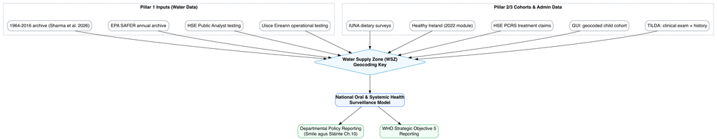

Figure 2: Data Linkage Architecture

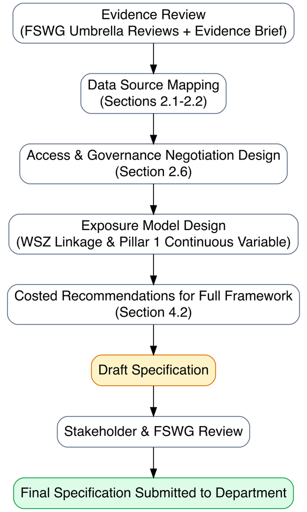

Figure 3: Specification Development Process